# DATA 622 Assignment 1

Amanda Fox

March 2, 2025

#### Intent

This document contains all code and figures for Assignment 1, to accompany my essay.

#### Libraries and Data

I began by loading set of libraries and the raw dataset:

```r
library(tidyverse)
library(ggplot2)
library(purrr)
library(knitr)
library(scales)
library(reshape2)
library(GGally)

df <- read_delim("https://raw.githubusercontent.com/AmandaSFox/DATA622/refs/heads/main/Assignment_1/bank-full.csv",
                 delim = ";",
                 quote = "\"")
```

#### Overview of Data

Glimpse provides a quick and easy initial look at the data. Missing data and duplicate records were verified, and column names changed to be more intuitive based on the documentation:

```r
glimpse(df)
```

```
## Rows: 45,211
## Columns: 17
## $ age       <dbl> 58, 44, 33, 47, 33, 35, 28, 42, 58, 43, 41, 29, 53, 58, 57, …
## $ job       <chr> "management", "technician", "entrepreneur", "blue-collar", "…
## $ marital   <chr> "married", "single", "married", "married", "single", "marrie…
## $ education <chr> "tertiary", "secondary", "secondary", "unknown", "unknown", …
## $ default   <chr> "no", "no", "no", "no", "no", "no", "no", "yes", "no", "no",…
## $ balance   <dbl> 2143, 29, 2, 1506, 1, 231, 447, 2, 121, 593, 270, 390, 6, 71…
## $ housing   <chr> "yes", "yes", "yes", "yes", "no", "yes", "yes", "yes", "yes"…
## $ loan      <chr> "no", "no", "yes", "no", "no", "no", "yes", "no", "no", "no"…
## $ contact   <chr> "unknown", "unknown", "unknown", "unknown", "unknown", "unkn…
## $ day       <dbl> 5, 5, 5, 5, 5, 5, 5, 5, 5, 5, 5, 5, 5, 5, 5, 5, 5, 5, 5, 5, …
## $ month     <chr> "may", "may", "may", "may", "may", "may", "may", "may", "may…
## $ duration  <dbl> 261, 151, 76, 92, 198, 139, 217, 380, 50, 55, 222, 137, 517,…
## $ campaign  <dbl> 1, 1, 1, 1, 1, 1, 1, 1, 1, 1, 1, 1, 1, 1, 1, 1, 1, 1, 1, 1, …
## $ pdays     <dbl> -1, -1, -1, -1, -1, -1, -1, -1, -1, -1, -1, -1, -1, -1, -1, …
## $ previous  <dbl> 0, 0, 0, 0, 0, 0, 0, 0, 0, 0, 0, 0, 0, 0, 0, 0, 0, 0, 0, 0, …
## $ poutcome  <chr> "unknown", "unknown", "unknown", "unknown", "unknown", "unkn…
## $ y         <chr> "no", "no", "no", "no", "no", "no", "no", "no", "no", "no", …
```

```r
# missing data
colSums(is.na(df))
```

```
##       age       job   marital education   default   balance   housing      loan
##         0         0         0         0         0         0         0         0
##   contact       day     month  duration  campaign     pdays  previous  poutcome
##         0         0         0         0         0         0         0         0
##         y
##         0
```

```r
# duplicate records
nrow(df) - nrow(distinct(df))
```

```
## [1] 0
```

```r
# change col names based on documentation
df_final <- df %>%
  set_names("Age","Occupation","Marital_Status","Education",
            "In_Default","Avg_Balance","Housing_Loan","Personal_Loan",
            "Contact_Type","Day","Month","Duration","Contacts_This_Campaign",
            "Days_Since_Last_Campaign","Contacts_Before_This_Campaign",
            "Previous_Outcome","Y")
```

#### Categorical Variables

Simple frequency distributions were done for all categorical features to check for **class imbalance** and to get to know our data better, keeping our business perspective in mind.

```r
# categorical column list
cat_cols <- df_final %>%
  select(where(is.character)) %>%
  names()

for (col in cat_cols) {
   df_final %>%
    count(.data[[col]]) %>%
    mutate(Pct = round((n / sum(n)) * 100, 1)) %>%
    arrange(desc(Pct)) %>%
    print()
}
```

```
## # A tibble: 12 × 3
##    Occupation        n   Pct
##    <chr>         <int> <dbl>
##  1 blue-collar    9732  21.5
##  2 management     9458  20.9
##  3 technician     7597  16.8
##  4 admin.         5171  11.4
##  5 services       4154   9.2
##  6 retired        2264   5
##  7 self-employed  1579   3.5
##  8 entrepreneur   1487   3.3
##  9 unemployed     1303   2.9
## 10 housemaid      1240   2.7
## 11 student         938   2.1
## 12 unknown         288   0.6
## # A tibble: 3 × 3
##   Marital_Status     n   Pct
##   <chr>          <int> <dbl>
## 1 married        27214  60.2
## 2 single         12790  28.3
## 3 divorced        5207  11.5
## # A tibble: 4 × 3
##   Education     n   Pct
##   <chr>     <int> <dbl>
## 1 secondary 23202  51.3
## 2 tertiary  13301  29.4
## 3 primary    6851  15.2
## 4 unknown    1857   4.1
## # A tibble: 2 × 3
##   In_Default     n   Pct
##   <chr>      <int> <dbl>
## 1 no         44396  98.2
## 2 yes          815   1.8
## # A tibble: 2 × 3
##   Housing_Loan     n   Pct
##   <chr>        <int> <dbl>
## 1 yes          25130  55.6
## 2 no           20081  44.4
## # A tibble: 2 × 3
##   Personal_Loan     n   Pct
```

[output cut: 21 more lines]

```
## 10 sep     579   1.3
## 11 mar     477   1.1
## 12 dec     214   0.5
## # A tibble: 4 × 3
##   Previous_Outcome     n   Pct
##   <chr>            <int> <dbl>
## 1 unknown          36959  81.7
## 2 failure           4901  10.8
## 3 other             1840   4.1
## 4 success           1511   3.3
## # A tibble: 2 × 3
##   Y         n   Pct
##   <chr> <int> <dbl>
## 1 no    39922  88.3
## 2 yes    5289  11.7
```

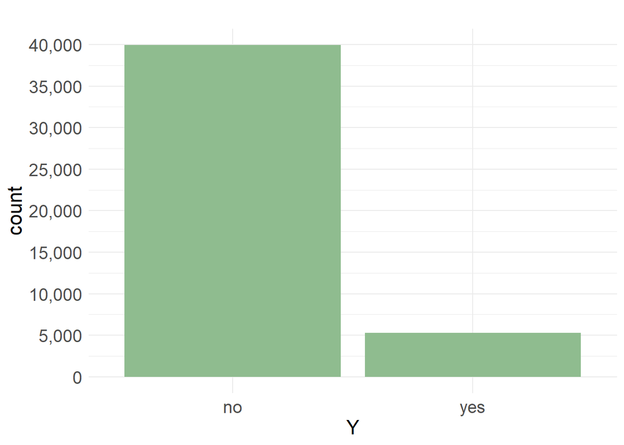

```r
# Selected Plots for Essay
plot_label <- df_final %>%
  ggplot(aes(x = Y, fill = Y)) +
  geom_bar(fill="darkseagreen") +
  labs(title = "") +
  scale_y_continuous(labels = scales::comma, breaks = seq(0, 50000, by = 5000)) +
  theme_minimal() +
  theme(legend.position = "none",
        axis.text.x = element_text(size = 14),
        axis.title.x = element_text(size = 16),
        axis.title.y = element_text(size = 16),
        axis.text.y = element_text(size = 14))

print(plot_label)
```

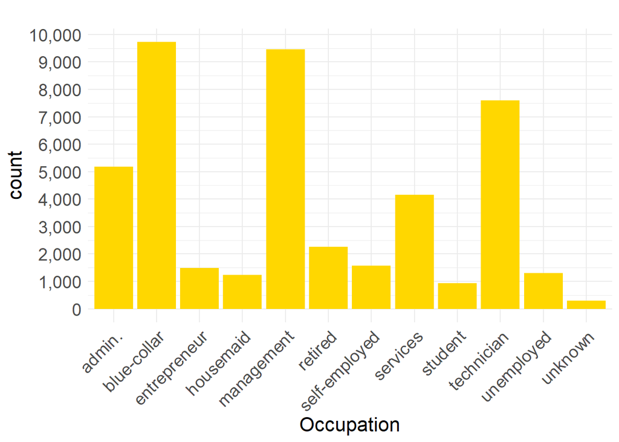

```r
plot_occupation <- df_final %>%
  ggplot(aes(x = Occupation, fill = Y)) +
  geom_bar(fill="gold") +
  scale_y_continuous(labels = scales::comma, breaks = seq(0, 50000, by = 1000)) +
  labs(title = "",) +
  theme_minimal() +
  theme(legend.position = "none",
        axis.text.x = element_text(angle = 45, hjust = 1, size = 14),
        axis.title.x = element_text(size = 16),
        axis.title.y = element_text(size = 16),
        axis.text.y = element_text(size = 14))

print(plot_occupation)
```